# using_jupyter_nb

```python
import pandas as pd
white_house = pd.read_csv("2015_white_house.csv")
print(white_house.shape)
```

```
(474, 5)
```

```python
print(white_house.iloc[0])
print(white_house.iloc[len(white_house.index)-1])
```

```
Name              Abdullah, Hasan A.
Status                      Detailee
Salary                        105960
Pay Basis                  Per Annum
Position Title        POLICY ADVISOR
Name: 0, dtype: object
Name                                             Zients, Jeffrey D.
Status                                                     Employee
Salary                                                       173922
Pay Basis                                                 Per Annum
Position Title    ASSISTANT TO THE PRESIDENT FOR ECONOMIC POLICY...
Name: 473, dtype: object
```

```python
white_house
```

|  | Name | Status | Salary | Pay Basis | Position Title |
| --- | --- | --- | --- | --- | --- |
| 0 | Abdullah, Hasan A. | Detailee | 105960 | Per Annum | POLICY ADVISOR |
| 1 | Abraham, Sabey M. | Employee | 55000 | Per Annum | ENERGY AND ENVIRONMENT DIRECTOR FOR PRESIDENTI... |
| 2 | Abraham, Yohannes A. | Employee | 121200 | Per Annum | SPECIAL ASSISTANT TO THE PRESIDENT AND CHIEF O... |
| 3 | Abramson, Jerry E. | Employee | 155035 | Per Annum | DEPUTY ASSISTANT TO THE PRESIDENT AND DIRECTOR... |
| 4 | Adler, Caroline E. | Employee | 114000 | Per Annum | SPECIAL ASSISTANT TO THE PRESIDENT AND DIRECTO... |
| 5 | Aiyer, Vikrum D. | Detailee | 134662 | Per Annum | SENIOR POLICY ADVISOR |
| 6 | Alcantara, Elias | Employee | 65650 | Per Annum | ASSOCIATE DIRECTOR OF INTERGOVERNMENTAL AFFAIRS |
| 7 | Ali, Mohammed I. | Employee | 42000 | Per Annum | STAFF ASSISTANT |
| 8 | Allen, Angelica P. | Employee | 50000 | Per Annum | SPECIAL ASSISTANT TO THE DIRECTOR OF THE OFFIC... |
| 9 | Allen, Elizabeth M. | Employee | 103000 | Per Annum | SPECIAL ASSISTANT TO THE PRESIDENT FOR MESSAGE... |
| 10 | Allen, Jessica L. | Employee | 42844 | Per Annum | PRESS ASSISTANT |
| 11 | Allison, Ashley R. | Employee | 97000 | Per Annum | DEPUTY DIRECTOR OF PUBLIC ENGAGEMENT |
| 12 | Amendolare, Vincent C. | Employee | 42420 | Per Annum | ANALYST |
| 13 | Amuluru, Uma M. | Detailee | 116804 | Per Annum | ASSOCIATE COUNSEL |
| 14 | Anderson, Amanda D. | Employee | 126250 | Per Annum | SPECIAL ASSISTANT TO THE PRESIDENT AND HOUSE L... |
| 15 | Anderson, Charles D. | Employee | 101000 | Per Annum | SENIOR ADVISOR FOR THE NATIONAL ECONOMIC COUNCIL |
| 16 | Aniskoff, Paulette L. | Employee | 155035 | Per Annum | DEPUTY ASSISTANT TO THE PRESIDENT AND DIRECTOR... |
| 17 | Ashton, Nathaniel R. | Employee | 42000 | Per Annum | STAFF ASSISTANT |
| 18 | Austin, Jr., Roy L. | Employee | 160085 | Per Annum | DEPUTY ASSISTANT TO THE PRESIDENT FOR THE OFFI... |
| 19 | Axios, Ashleigh T. | Employee | 73225 | Per Annum | DIGITAL CREATIVE DIRECTOR |
| 20 | Babajide, Ayotunde T. | Detailee | 114480 | Per Annum | SENIOR POLICY ADVISOR |
| 21 | Bae, Yena | Employee | 44000 | Per Annum | SENIOR ANALYST AND PROJECT MANAGER |
| 22 | Baker, Sarah E. | Employee | 131805 | Per Annum | SPECIAL ASSISTANT TO THE PRESIDENT AND ASSOCIA... |
| 23 | Bansal, Gaurab | Employee | 120000 | Per Annum | DEPUTY ASSISTANT TO THE PRESIDENT AND DEPUTY C... |
| 24 | Barnes, Desiree N. | Employee | 42844 | Per Annum | PRESS ASSISTANT |
| 25 | Bartoloni, Kristen A. | Employee | 70000 | Per Annum | DEPUTY DIRECTOR OF RESEARCH |
| 26 | Beckford, Kevin F. | Employee | 42000 | Per Annum | ANALYST |
| 27 | Beliveau, Emmett S. | Employee | 160085 | Per Annum | ASSISTANT TO THE PRESIDENT AND DIRECTOR OF THE... |
| 28 | Benenati, Frank J. | Employee | 84840 | Per Annum | ASSISTANT PRESS SECRETARY |
| 29 | Bennett, Tabitha R. | Employee | 50000 | Per Annum | PRESS LEAD |
| ... | ... | ... | ... | ... | ... |
| 444 | Vignarajah, Krishanti | Employee | 90000 | Per Annum | DIRECTOR OF INTERNATIONAL AFFAIRS AND SENIOR P... |
| 445 | Vilfer, Ryan E. | Employee | 42420 | Per Annum | STAFF ASSISTANT |
| 446 | Vorhaus, David A. | Employee | 111100 | Per Annum | SPECIAL ASSISTANT TO THE PRESIDENT AND ADVISOR... |
| 447 | Vrazilek, Lauren S. | Employee | 55000 | Per Annum | DEPUTY PRESS SECRETARY FOR THE FIRST LADY |
| 448 | Wagstaff, Jesica E. | Employee | 45905 | Per Annum | LEGISLATIVE ASSISTANT AND ASSISTANT TO THE SEN... |
| 449 | Waheed, Manar | Employee | 80800 | Per Annum | DEPUTY POLICY DIRECTOR FOR IMMIGRATION |
| 450 | Wainscott, Kip F. | Detailee | 134662 | Per Annum | SENIOR DIRECTOR OF CABINET AFFAIRS |
| 451 | Waldo, Katherine A. | Employee | 47470 | Per Annum | TRIP COORDINATOR |
| 452 | Wall, Alexander B. | Employee | 63125 | Per Annum | DEPUTY DIRECTOR OF ONLINE ENGAGEMENT |
| 453 | Walsh, James D. | Detailee | 171871 | Per Annum | ASSOCIATE COUNSEL |
| 454 | Walsh, Joan L. | Employee | 160085 | Per Annum | DEPUTY ASSISTANT TO THE PRESIDENT AND STAFF SE... |
| 455 | Wang, Ya W. | Employee | 85000 | Per Annum | SPECIAL ASSISTANT AND ADVISOR TO THE CHIEF OF ... |
| 456 | Whisenant, Addie M. | Employee | 78780 | Per Annum | DIRECTOR OF AFRICAN-AMERICAN MEDIA |
| 457 | Wild, Clayton S. | Employee | 44000 | Per Annum | PRESIDENTIAL WRITER |
| 458 | Wilkinson, Jr., David E. | Employee | 100000 | Per Annum | DIRECTOR, OFFICE OF SOCIAL INNOVATION AND CIVI... |
| 459 | Williams, Sherman A. | Employee | 80716 | Per Annum | ASSISTANT TO THE EXECUTIVE CLERK |
| 460 | Winter, Melissa E. | Employee | 133320 | Per Annum | DEPUTY ASSISTANT TO THE PRESIDENT AND SENIOR A... |
| 461 | Wong, Jacqueline | Employee | 58075 | Per Annum | SENIOR POLICY ANALYST |
| 462 | Wright, Frank B. | Employee | 65000 | Per Annum | DEPUTY DIRECTOR FOR FINANCE |
| 463 | Wu, Alexander P. | Employee | 52520 | Per Annum | ASSOCIATE DIRECTOR FOR THE MANAGEMENT AND ADMI... |
| 464 | Xharda, Klevis | Employee | 42420 | Per Annum | EXECUTIVE ASSISTANT |
| 465 | Yaros, Stephen G. | Employee | 42000 | Per Annum | STAFF ASSISTANT |
| 466 | Young, Caitlin E. | Employee | 63630 | Per Annum | STENOGRAPHER |
| 467 | Young, Jr., Reginald D. | Employee | 69597 | Per Annum | SENIOR MANAGEMENT ANALYST |
| 468 | Young, Kimberly E. | Employee | 45000 | Per Annum | LEGISLATIVE ASSISTANT |
| 469 | Young, Stephanie L. | Employee | 87870 | Per Annum | ASSOCIATE COMMUNICATIONS DIRECTOR |
| 470 | Young, Valerie A. | Employee | 52667 | Per Annum | RECORDS MANAGEMENT ANALYST |
| 471 | Yudelson, Alex R. | Employee | 42000 | Per Annum | STAFF ASSISTANT |
| 472 | Zaid, Zaid A. | Detailee | 158700 | Per Annum | ASSOCIATE COUNSEL |
| 473 | Zients, Jeffrey D. | Employee | 173922 | Per Annum | ASSISTANT TO THE PRESIDENT FOR ECONOMIC POLICY... |

474 rows × 5 columns

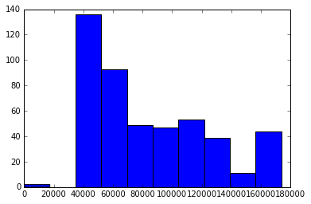

```python
%matplotlib inline
import matplotlib.pyplot as plt

plt.hist(white_house["Salary"])
plt.show()
```

**Jupyter Notebook Guided Project**

This project is a great introduction to using Jupyter notebooks for data science. It emphasizes the ability to mix code, formated results, and graphics to build a *story* that others can follow.

**Additional Questions:**

- How does length of employee titles correlate to salary?
- How much does the White House pay in total salary?
- Who are the highest and lowest paid staffers?
- What words are the most common in titles?

**Question 1: Title Length vs Salary**

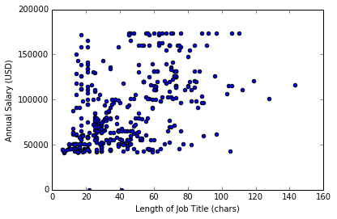

```python
title_lengths = white_house['Position Title'].apply(lambda x: len(x))

plt.scatter(title_lengths, white_house['Salary'])
plt.xlim(0, 160)
plt.ylim(0, 200000)
plt.xlabel('Length of Job Title (chars)')
plt.ylabel('Annual Salary (USD)')
plt.show()
```

**Answer 1:** There appears to be a very weak positive correlation between job title and annual salary

**Question 2: Total Salary Payments**

```python
total_salary = white_house['Salary'].sum()
num_employees = len(white_house.index)
ave_salary = total_salary / num_employees

print('Total Salary Payments (USD): %i' % total_salary)
print('Number of Employees: %i' % num_employees)
print('Average Salary (USD): %i' % ave_salary)
```

```
Total Salary Payments (USD): 40225595
Number of Employees: 474
Average Salary (USD): 84864
```

**Answer 2:** The White House spends ~40 million dollars a year on salary for its 474 employees. The average salary is ~$84,000.

**Question 3: Highest and Lowest Paid Staffers**

```python
# finds the minimum salary and the employee(s) who make it
min_salary = white_house['Salary'].min()
employees_have_min = (white_house['Salary'] == min_salary)
employees_with_min = white_house[['Name','Position Title']].loc[employees_have_min]
print('Minimum Salary: %i' % min_salary)
print(employees_with_min)
print('\n')

# finds the maximum salary and the employee(s) who make it
max_salary = white_house['Salary'].max()
employees_have_max = (white_house['Salary'] == max_salary)
employees_with_max = white_house[['Name','Position Title']].loc[employees_have_max]
print('Maximum Salary: %i' % max_salary)
print(employees_with_max)
```

```
Minimum Salary: 0
                    Name                             Position Title
243  Leary, Kimberlyn R.  ADVISOR TO THE COUNCIL ON WOMEN AND GIRLS
326        Park, Todd Y.                     ADVISOR FOR TECHNOLOGY


Maximum Salary: 173922
                       Name                                     Position Title
52   Breckenridge, Anita J.  ASSISTANT TO THE PRESIDENT AND DEPUTY CHIEF OF...
70    Canegallo, Kristie A.  ASSISTANT TO THE PRESIDENT AND DEPUTY CHIEF OF...
90        Cushman, Chase M.  ASSISTANT TO THE PRESIDENT AND DIRECTOR OF SCH...
117      Earnest, Joshua R.     ASSISTANT TO THE PRESIDENT AND PRESS SECRETARY
121    Eggleston, Warren N.  ASSISTANT TO THE PRESIDENT AND COUNSEL TO THE ...
130   Fallon, Katherine B.   ASSISTANT TO THE PRESIDENT AND DIRECTOR OF THE...
200     Jarrett, Valerie B.  SENIOR ADVISOR AND ASSISTANT TO THE PRESIDENT ...
201   Johnson, Broderick D.   ASSISTANT TO THE PRESIDENT AND CABINET SECRETARY
210           Kale, Katy A.  ASSISTANT TO THE PRESIDENT FOR MANAGEMENT AND ...
216         Keenan, Cody S.  ASSISTANT TO THE PRESIDENT AND DIRECTOR OF SPE...
280     McDonough, Denis R.      ASSISTANT TO THE PRESIDENT AND CHIEF OF STAFF
297         Monaco, Lisa O.  ASSISTANT TO THE PRESIDENT FOR HOMELAND SECURI...
304         Muñoz, Cecilia   ASSISTANT TO THE PRESIDENT AND DIRECTOR OF THE...
358     Rhodes, Benjamin J.  ASSISTANT TO THE PRESIDENT AND DEPUTY NATIONAL...
359          Rice, Susan E.  ASSISTANT TO THE PRESIDENT AND NATIONAL SECURI...
403         Simas, David M.  ASSISTANT TO THE PRESIDENT AND DIRECTOR OF THE...
426     Tchen, Christina M.  ASSISTANT TO THE PRESIDENT AND CHIEF OF STAFF ...
473      Zients, Jeffrey D.  ASSISTANT TO THE PRESIDENT FOR ECONOMIC POLICY...
```

**Answer 3:** The lowest paid staffers don't get paid at all, and the highest paid staffers receive a salary of ~$174,000. See the lists above for the names and job titles of the individuals in each category.

**Question 4: Most Common Words in Job Titles**

```python
words = {}
positions = set(list(white_house['Position Title']))

for pos in positions:
    title_parts = pos.split(' ')
    for part in title_parts:
        if part in words:
            words[part] += 1
        else:
            words[part] = 1

word_text = list(words.keys())
word_count = list(words.values())

word_series = pd.Series(index=word_text, data=word_count)
word_series.sort_values(ascending=False, inplace=True)
print(word_series[0:10])
```

```
THE          177
AND          143
OF           142
ASSISTANT    140
TO           131
DIRECTOR     128
PRESIDENT     96
FOR           82
SPECIAL       72
DEPUTY        71
dtype: int64
```

**Answer 4:** The most common words in White House job titles are articles. Beyond those (they are irrelevant to this analysis), the five most common words are "Assistant", "Director", "President", "Special" and "Deputy".